# Assignment 3 Advanced Statistical Modeling

s3432548

Eser Comak

## Preparations

- Download the data and load it in R:

```r
# clean R working environment:
rm(list=ls())

# Load data:
load("DykesRivers.rda")

# Load packages:
library(plyr)
library(plotfunctions)
library(mgcv)
library(itsadug)
# inspect data:
head(dat)
```

```
##          subj cond block n.block seq2 dur2      rt2 errE2 errL2 seq3 dur3
## 1 81112112644   DR     1      46    1 2000 1856.376 FALSE FALSE    2 3100
## 2 81112112644   DR     1      46    3 2000 2298.246 FALSE  TRUE    4 3100
## 3 81112112644   DR     1      46    5 2000 1708.988  TRUE FALSE    6 3100
## 4 81112112644   DR     1      46    7 2000 2057.195 FALSE FALSE    8 3100
## 5 81112112644   DR     1      46    9 2000 2164.245 FALSE FALSE   10 3100
## 6 81112112644   DR     1      46   11 2000 2391.830 FALSE  TRUE   12 3100
##        rt3 errE3 errL3
## 1 3529.841 FALSE  TRUE
## 2 3021.203 FALSE FALSE
## 3 2887.248 FALSE FALSE
## 4 3610.293 FALSE  TRUE
## 5 3288.889 FALSE FALSE
## 6 3436.151 FALSE FALSE
```

```r
str(dat)
```

```
## 'data.frame':    8761 obs. of  14 variables:
##  $ subj   : Factor w/ 48 levels "81112112644",..: 1 1 1 1 1 1 1 1 1 1 ...
##  $ cond   : Factor w/ 3 levels "DR","FF","RD": 1 1 1 1 1 1 1 1 1 1 ...
##  $ block  : int  1 1 1 1 1 1 1 1 1 1 ...
##  $ n.block: num  46 46 46 46 46 46 46 46 46 46 ...
##  $ seq2   : num  1 3 5 7 9 11 13 15 17 19 ...
##  $ dur2   : int  2000 2000 2000 2000 2000 2000 2000 2000 2000 2000 ...
##  $ rt2    : num  1856 2298 1709 2057 2164 ...
##  $ errE2  : logi  FALSE FALSE TRUE FALSE FALSE FALSE ...
##  $ errL2  : logi  FALSE TRUE FALSE FALSE FALSE TRUE ...
##  $ seq3   : num  2 4 6 8 10 12 14 16 18 20 ...
##  $ dur3   : int  3100 3100 3100 3100 3100 3100 3100 3100 3100 3100 ...
##  $ rt3    : num  3530 3021 2887 3610 3289 ...
##  $ errE3  : logi  FALSE FALSE FALSE FALSE FALSE FALSE ...
##  $ errL3  : logi  TRUE FALSE FALSE TRUE FALSE FALSE ...
```

## PART I: Descriptive statistics

```r
table(dat$subj, dat$cond)
```

```
##
##                DR  FF  RD
##   81112112644 183   0   0
##   81113105409   0   0 183
##   81113113938 183   0   0
##   81114092619   0   0 183
##   81114100422   0   0 183
##   81114113726 183   0   0
##   81114121240 183   0   0
##   81117091626   0   0 183
##   81117092623 183   0   0
##   81117100546   0   0 183
##   81117104859 183   0   0
##   81117113740   0   0 183
##   81118091748 183   0   0
```

[output cut: 35 more lines]

is Condition (cond) a within-subjects predictor or a between-subjects predictor?

It is between subjects predictor. Each participant participated in one level of the experiment

The duration of the short interval did not change:

```r
table(dat$dur2)
```

```
##
## 2000
## 8761
```

The plot below show how the duration of the long interval changes with the conditions (you may also want to look at the plots in the paper).

```r
table(dat$dur3)
```

```
##
## 2600 2625 2633 2659 2666 2693 2699 2727 2732 2761 2765 2795 2798 2829 2831
##  800   32   32   32   32   32   32   32   32   32   32   32   32   32   32
## 2863 2864 2897 2930 2931 2963 2965 2996 2999 3029 3033 3062 3067 3095 3100
##   32   32   64   32   32   32   32   32   32   32   32   32   32   32 5305
## 3125 3133 3159 3166 3193 3199 3227 3232 3261 3265 3295 3298 3329 3331 3363
##   32   32   32   32   32   32   32   32   32   32   32   32   32   32   32
## 3364 3397 3430 3431 3463 3465 3496 3499 3529 3533 3562 3567 3595 3600
##   32   64   32   32   32   32   32   32   32   32   32   32   32  800
```

```r
# data frame with durations of the long interval to reproduce
# for each trial (seq) and condition (cond):
conditions <- dat[,c("seq3", "dur3", "cond")]
# remove duplicate rows:
conditions <- conditions[!duplicated(conditions),]
head(conditions)
```

```
##   seq3 dur3 cond
## 1    2 3100   DR
## 2    4 3100   DR
## 3    6 3100   DR
## 4    8 3100   DR
## 5   10 3100   DR
## 6   12 3100   DR
```

```r
# data frame with block lengths:
blocks <- tapply(dat$rt3, list(dat$block, dat$subj), length)
blocks
```

```
##   81112112644 81113105409 81113113938 81114092619 81114100422 81114113726
## 1          23          23          23          23          23          23
## 2          17          17          17          17          17          17
## 3          23          23          23          23          23          23
## 4          17          17          17          17          17          17
## 5          23          23          23          23          23          23
## 6          17          17          17          17          17          17
## 7          23          23          23          23          23          23
## 8          17          17          17          17          17          17
## 9          23          23          23          23          23          23
##   81114121240 81117091626 81117092623 81117100546 81117104859 81117113740
## 1          23          23          23          23          23          23
## 2          17          17          17          17          17          17
## 3          23          23          23          23          23          23
## 4          17          17          17          17          17          17
```

[output cut: 65 more lines]

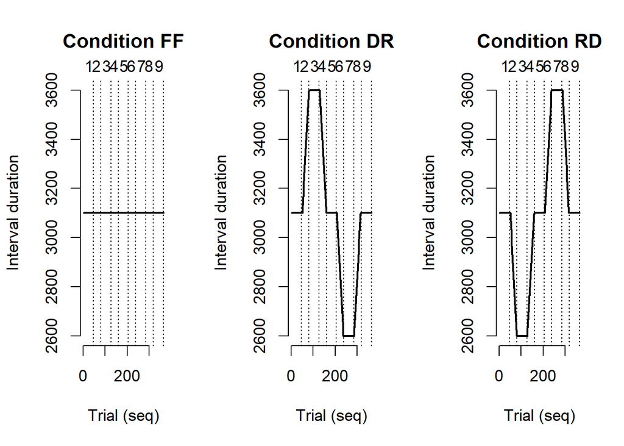

```r
# get the row means (we could have also taken just one column):
blocks <- rowMeans(blocks, na.rm = TRUE)

### PLOTS: ######################################

# split plot window in three panels:
par(mfrow=c(1,3), cex=1.1)

## PLOT 1:
# setup empty plot:
plot(c(), c(),
     xlim=c(1,max(dat$seq3)), ylim=range(dat$dur3),
     main="Condition FF", xlab="Trial (seq)", ylab="Interval duration",
     bty='n')
# add line for FF:
with(conditions[conditions$cond=="FF",], lines(seq3, dur3, lwd=2))
# add block numbers (blocks need to get multiplied with 2, because
# participants need to reproduce the short and the long interval):
abline(v=cumsum(blocks*2), lty=3)
# add block numbers:
# note that xpd=TRUE allows for putting info outside plot region
text(cumsum(blocks*2), rep(3700, length(blocks)), labels=names(blocks), adj=1, xpd=TRUE)

## PLOT 2:
plot(c(), c(),
     xlim=c(1,max(dat$seq3)), ylim=range(dat$dur3),
     main="Condition DR", xlab="Trial (seq)", ylab="Interval duration",
     bty='n')
with(conditions[conditions$cond=="DR",], lines(seq3, dur3, lwd=2))
abline(v=cumsum(blocks*2), lty=3)
text(cumsum(blocks*2), rep(3700, length(blocks)), labels=names(blocks), adj=1, xpd=TRUE)

## PLOT 3:
plot(c(), c(),
     xlim=c(1,max(dat$seq3)), ylim=range(dat$dur3),
     main="Condition RD", xlab="Trial (seq)", ylab="Interval duration",
     bty='n')
with(conditions[conditions$cond=="RD",], lines(seq3, dur3, lwd=2))
abline(v=cumsum(blocks*2), lty=3)
text(cumsum(blocks*2), rep(3700, length(blocks)), labels=names(blocks), adj=1, xpd=TRUE)
```

The columns rt2 and rt3 show the estimated durations for the short and long intervals. Below example code is provided for the reaction times per condition and the SE of the means.

```r
avg <- ddply(dat, c("seq2", "cond", "subj"), summarise,
              RTshort = mean(rt2, na.rm=TRUE),
              RTlong  = mean(rt3, na.rm=TRUE))
# by adding 0.5 to seq2, we take the average between seq2 and seq3
# as a representation of the trial number. Recall that short and long
# intervals were alternating.
avg$Trial <- avg$seq2 + 0.5

avg <- ddply(avg, c("Trial", "cond"), summarise,
              m.RTshort = mean(RTshort, na.rm=TRUE),
              s.RTshort = se(RTshort, na.rm=TRUE),
              m.RTlong = mean(RTlong, na.rm=TRUE),
              s.RTlong = se(RTlong, na.rm=TRUE))
head(avg)
```

```
##   Trial cond m.RTshort s.RTshort m.RTlong s.RTlong
## 1   1.5   DR  2073.844 103.24633 2981.084 122.0771
## 2   1.5   FF  2297.510 108.06530 2875.228 150.0603
## 3   1.5   RD  2020.953  62.95658 2817.815 168.0994
## 4   3.5   DR  2018.170  67.88284 2863.457 128.0406
## 5   3.5   FF  2179.405 124.51079 2781.548 127.5722
## 6   3.5   RD  2133.182  63.15733 2762.221 135.2366
```

Here is an example plot of the data using R’s basic plot functions. (If you prefer to use ggplot or lattice for plotting, it might be a useful exercise for the exam to try to produce a similar graph with these packages.)

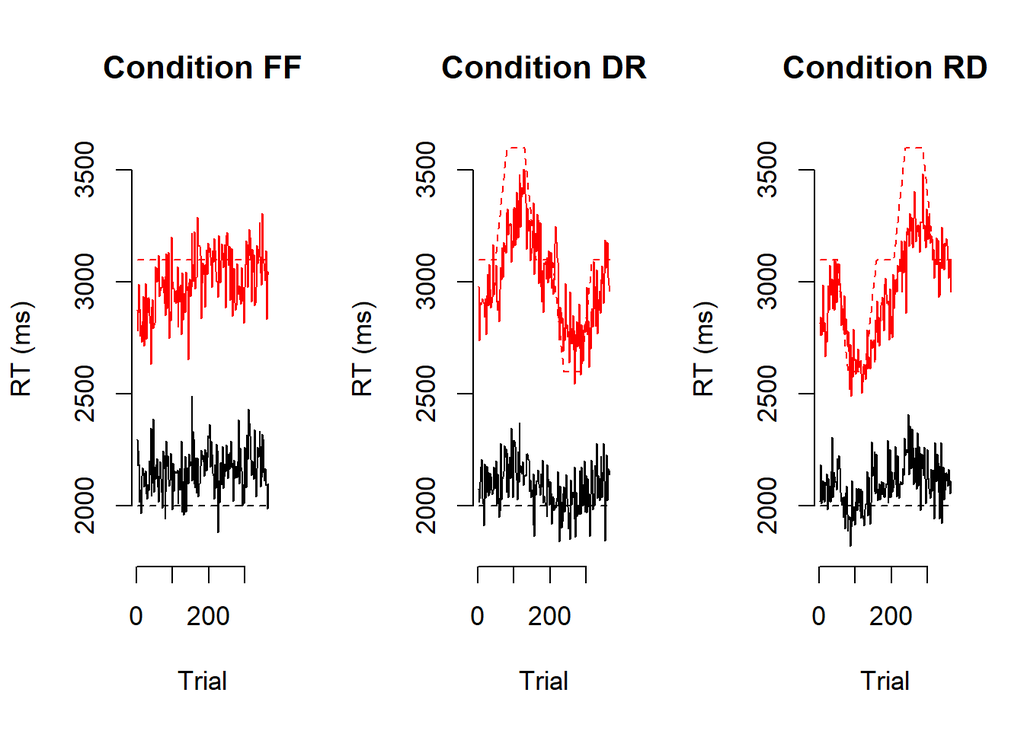

```r
# create three panels:
par(mfrow=c(1,3), cex=1.1)

# PLOT 1:
# setup empty plot window with large enough axes:
plot(c(), c(), xlim=range(avg$Trial), ylim=c(1800, 3600),
     main="Condition FF", xlab="Trial", ylab="RT (ms)",
     bty='n')
# run the next series of commands on the averages of condition FF:
# (note that the {} allow for multiple commands in the 'with' statement)
with(avg[avg$cond=="FF",], {
  lines(Trial, m.RTshort)
  lines(Trial, m.RTlong, col=2)
})
# run the next series of commands on the presented durations of condition FF:
with(conditions[conditions$cond=="FF",],{
  lines(seq3, dur3, col=2, lty=2)
  lines(seq3, rep(2000,length(seq3)), col=1, lty=2)
})

# PLOT 2:
plot(c(), c(), xlim=range(avg$Trial), ylim=c(1800, 3600),
     main="Condition DR", xlab="Trial", ylab="RT (ms)",
     bty='n')
with(avg[avg$cond=="DR",], {
  lines(Trial, m.RTshort)
  lines(Trial, m.RTlong, col=2)
})
with(conditions[conditions$cond=="DR",], {
  lines(seq3, dur3, col=2, lty=2)
  lines(seq3, rep(2000,length(seq3)), col=1, lty=2)
})

# PLOT 3:
plot(c(), c(), xlim=range(avg$Trial), ylim=c(1800, 3600),
     main="Condition RD", xlab="Trial", ylab="RT (ms)",
     bty='n')
with(avg[avg$cond=="RD",], {
  lines(Trial, m.RTshort)
  lines(Trial, m.RTlong, col=2)
})
with(conditions[conditions$cond=="RD",], {
  lines(seq3, dur3, col=2, lty=2)
  lines(seq3, rep(2000,length(seq3)), col=1, lty=2)
})
```

## PART II: Analysis

The question we would like to answer in this assignment is whether participant’s estimation of the short interval is influenced by the (changing) duration of the long interval. The column `rt2` contains the participants’ estimations of the short interval. Note that the short interval was kept constant at 2 seconds in all conditions.

#### Question 1: Data [4pt]

- Inspect the reaction times. Include the code and your answers to the following questions:
  - Describe the range of the reaction times

  ```r
  range(dat$rt2)
  ```

  ```
  ## [1]  169.5251 5775.1789
  ```

  it is between 169ms to 5775ms
  - Describe the distribution of the reaction times

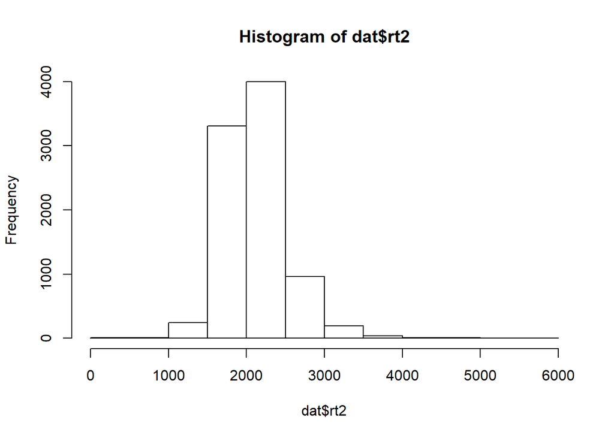

  ```r
  hist(dat$rt2)
  ```

  - Check for outliers. If you find outliers, describe why and how you removed these. If you do not find outliers, explain how you did conclude that there were no outliers to remove.

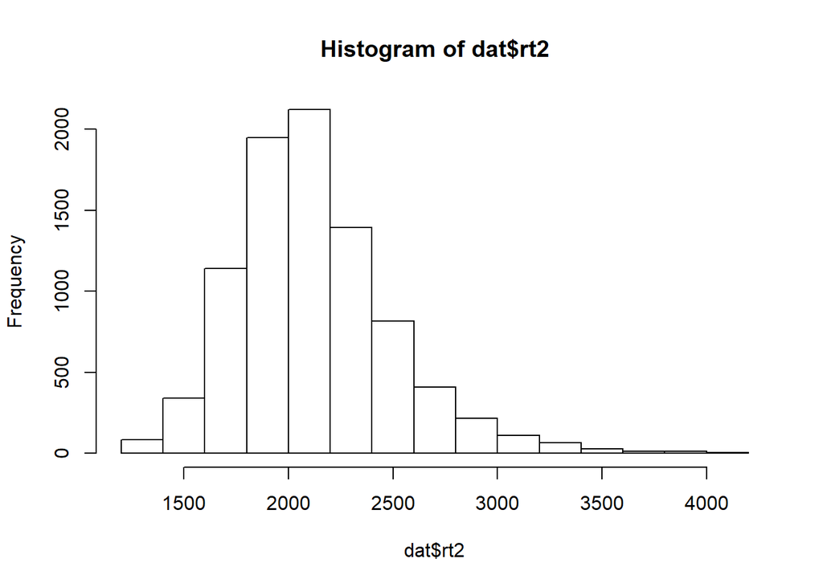

  ```r
  dat<-subset(dat, rt2 >= 1250 & rt2 <= 4250)
  hist(dat$rt2)
  ```

  In the provided paper, 12 subjects were removed from the pool because more than 3% of their responses were shorter than 1.25 s or longer than 4.25 s. Therefore following the same procedure in the paper, we opted to remove responses shorter than 1.25ms and longer than 4.25ms
- Decide whether you need to transform the data (describe why / why not) and which transformation would be best (and why). Include your code and your answers.
  - If you decided to transform the data, include the code for the actual transformation of the data.

#### Question 2: GAMM [6pt]

- Setup a GAMM model that includes the interaction between `cond` and `seq2` (which marks the trial).
- Also include a random effect(s) for participants (`subj`). And answer the following questions:
  - List all the possible random effects for `subj` (code and short description of the random effect), with only considering `cond` and `seq2` as other predictors that are available in the data. Hint: First, think about which different types of random effects are available in GAMMs.

```r
#Listing all possible random effects for subj with only considering cond and seq2
#s(subj, bs ="re") - random intercept for subj
#s(subj, cond, bs = "re") - by speaker random slope for each condition
#s(subj, seq2, bs = "re") -by speaker random slope for each trial
#s(seq2, subj, bs = "fs", m = 1) - random factor smooth for each subj considering the non-linear variability of each subj's performance over trials
#s(seq2, subj, by = cond, bs = "fs", m = 1) - random factor smooth for each subj considering the non-linear variability of each subj's performance over trials. This is furthermore applied to each condition (FF,DR,RD) with "by= cond" parameter
```

```
- Explain why you prefer the random effect(s) your selected to include. Hint: You do not need to do modelcomparisons to determine whicn random effects structure you prefer.
```

Run the model and include the code and summary in your report.

```r
#get feedback information for rt2 to test paper's findings
dat$errE2<-as.character(dat$errE2)
dat$errL2<-as.character(dat$errL2)
dat$rt2fb<- NA
dat$rt2fb[which(dat$errE2 == "FALSE" & dat$errL2 == "TRUE")]<- "LONG"
dat$rt2fb[which(dat$errE2 == "TRUE" & dat$errL2 == "FALSE")]<- "SHORT"
dat$rt2fb[which(dat$errE2 == "FALSE" & dat$errL2 == "FALSE")]<- "CORRECT"
dat$rt2fb<-as.factor(dat$rt2fb)

#model built by the specifications provided in the assignment
m1<- bam(rt2 ~ cond + s(seq2, by=cond) + s(seq2,subj,by=cond,bs="fs",m=1),data=dat)
summary(m1)
```

```
##
## Family: gaussian
## Link function: identity
##
## Formula:
## rt2 ~ cond + s(seq2, by = cond) + s(seq2, subj, by = cond, bs = "fs",
##     m = 1)
##
## Parametric coefficients:
##             Estimate Std. Error t value Pr(>|t|)
## (Intercept)  2092.43      31.98  65.430   <2e-16 ***
## condFF         69.52      47.24   1.472    0.141
## condRD          8.95      41.41   0.216    0.829
## ---
## Signif. codes:  0 '***' 0.001 '**' 0.01 '*' 0.05 '.' 0.1 ' ' 1
##
## Approximate significance of smooth terms:
##                        edf  Ref.df     F  p-value
## s(seq2):condDR       4.842   5.746 4.258 0.000376 ***
## s(seq2):condFF       1.001   1.001 0.151 0.697671
## s(seq2):condRD       6.993   7.975 5.170 3.06e-06 ***
## s(seq2,subj):condDR 58.854 143.000 2.131  < 2e-16 ***
## s(seq2,subj):condFF 61.091 143.000 3.902  < 2e-16 ***
## s(seq2,subj):condRD 53.314 143.000 2.287  < 2e-16 ***
## ---
## Signif. codes:  0 '***' 0.001 '**' 0.01 '*' 0.05 '.' 0.1 ' ' 1
##
## R-sq.(adj) =   0.14   Deviance explained = 15.9%
## fREML =  63429  Scale est. = 1.2103e+05  n = 8700
```

```r
#Below are the models that are built on the guidance of the findings provided in the paper
m2 <- bam(rt2 ~ cond+ s(seq2, by=cond) + s(seq2,subj, by= rt2fb, bs="fs" , m = 1),data=dat)
summary(m2)
```

```
##
## Family: gaussian
## Link function: identity
##
## Formula:
## rt2 ~ cond + s(seq2, by = cond) + s(seq2, subj, by = rt2fb, bs = "fs",
##     m = 1)
##
## Parametric coefficients:
##             Estimate Std. Error t value Pr(>|t|)
## (Intercept) 2007.617      7.264 276.383   <2e-16 ***
## condFF         3.933     10.376   0.379    0.705
## condRD        -8.728     10.217  -0.854    0.393
## ---
## Signif. codes:  0 '***' 0.001 '**' 0.01 '*' 0.05 '.' 0.1 ' ' 1
##
## Approximate significance of smooth terms:
##                              edf  Ref.df      F  p-value
## s(seq2):condDR              1.00   1.000  0.490    0.484
## s(seq2):condFF              1.00   1.000  0.115    0.734
## s(seq2):condRD              1.00   1.001  0.281    0.596
## s(seq2,subj):rt2fbCORRECT  27.10 432.000  0.170 7.89e-09 ***
## s(seq2,subj):rt2fbLONG    218.17 428.000 26.459  < 2e-16 ***
## s(seq2,subj):rt2fbSHORT    47.45 423.000  8.127  < 2e-16 ***
## ---
## Signif. codes:  0 '***' 0.001 '**' 0.01 '*' 0.05 '.' 0.1 ' ' 1
##
## R-sq.(adj) =  0.763   Deviance explained = 77.1%
## fREML =  58063  Scale est. = 33326     n = 8700
```

Here we first built the model according the configuration provided in the question. To account for the variability and dependency among measurements, we chose to include random factor smooth for subj to capture non-linear rt2 production trend over trials. Furthermore we assumed the trend might be different for each condition. Thus we additionally included “by = cond” parameter into our random factor smooth. Instead of adding random intercept and slope for subj separetely, we believed all the variability can be simply captured by random factor smooths

- Plot the fitted / summed effects with the function `plot_smooth`. Use the function `plot_diff` to plot the differences between the conditions FF and DR and between FF and RD.
  - What do you conclude about the differences between the conditions?

```
## Summary:
##  * cond : factor; set to the value(s): DR, FF, RD.
##  * seq2 : numeric predictor; with 30 values ranging from 1.000000 to 365.000000.
##  * subj : factor; set to the value(s): 81113113938. (Might be canceled as random effect, check below.)
##  * NOTE : The following random effects columns are canceled: s(seq2,subj):condDR,s(seq2,subj):condFF,s(seq2,subj):condRD
##
```

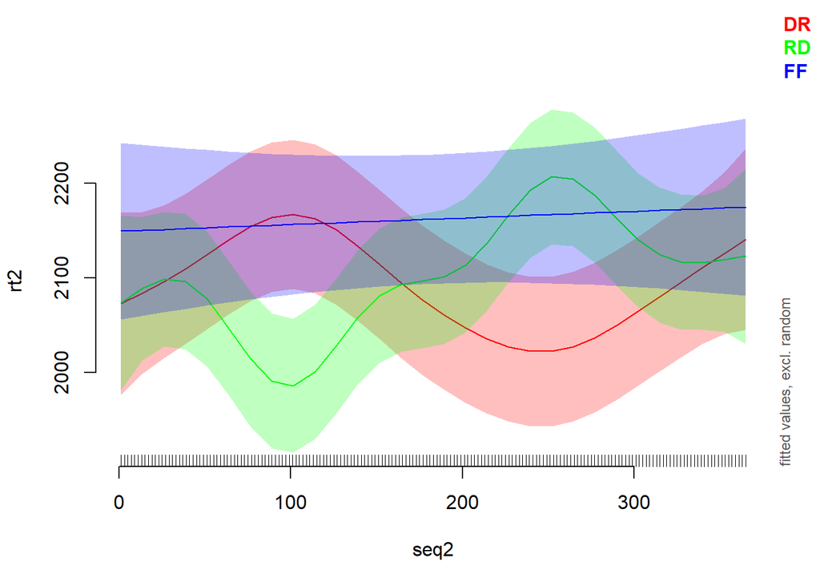

```r
plot_smooth(m1, view = "seq2" , plot_all= "cond", rm.ranef=TRUE)
```

```
## Summary:
##  * seq2 : numeric predictor; with 100 values ranging from 1.000000 to 365.000000.
##  * subj : factor; set to the value(s): 81113113938. (Might be canceled as random effect, check below.)
##  * NOTE : The following random effects columns are canceled: s(seq2,subj):condDR,s(seq2,subj):condFF,s(seq2,subj):condRD
##
```

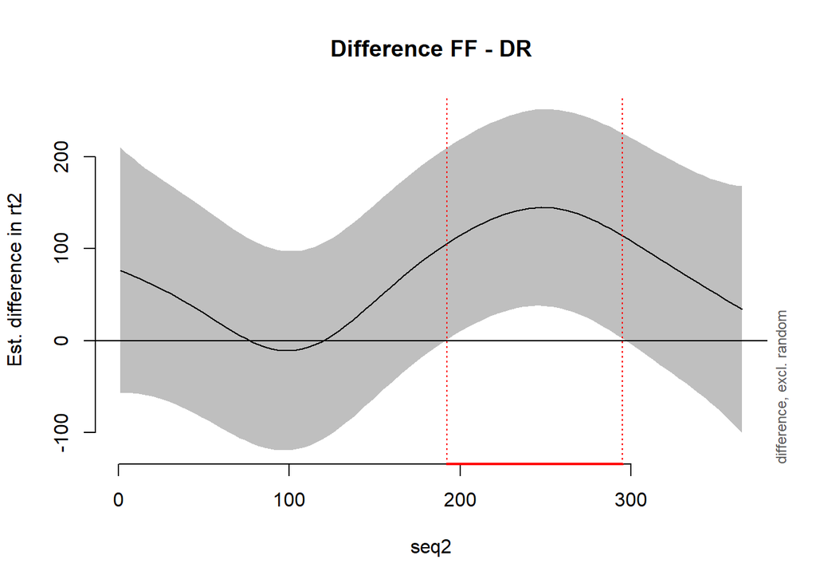

```
##
## seq2 window(s) of significant difference(s):
##  192.191919 - 295.141414
```

```r
plot_diff(m1, view= "seq2" , comp=list(cond=c("FF","DR")), rm.ranef=TRUE)
```

```
## Summary:
##  * seq2 : numeric predictor; with 100 values ranging from 1.000000 to 365.000000.
##  * subj : factor; set to the value(s): 81113113938. (Might be canceled as random effect, check below.)
##  * NOTE : The following random effects columns are canceled: s(seq2,subj):condDR,s(seq2,subj):condFF,s(seq2,subj):condRD
##
```

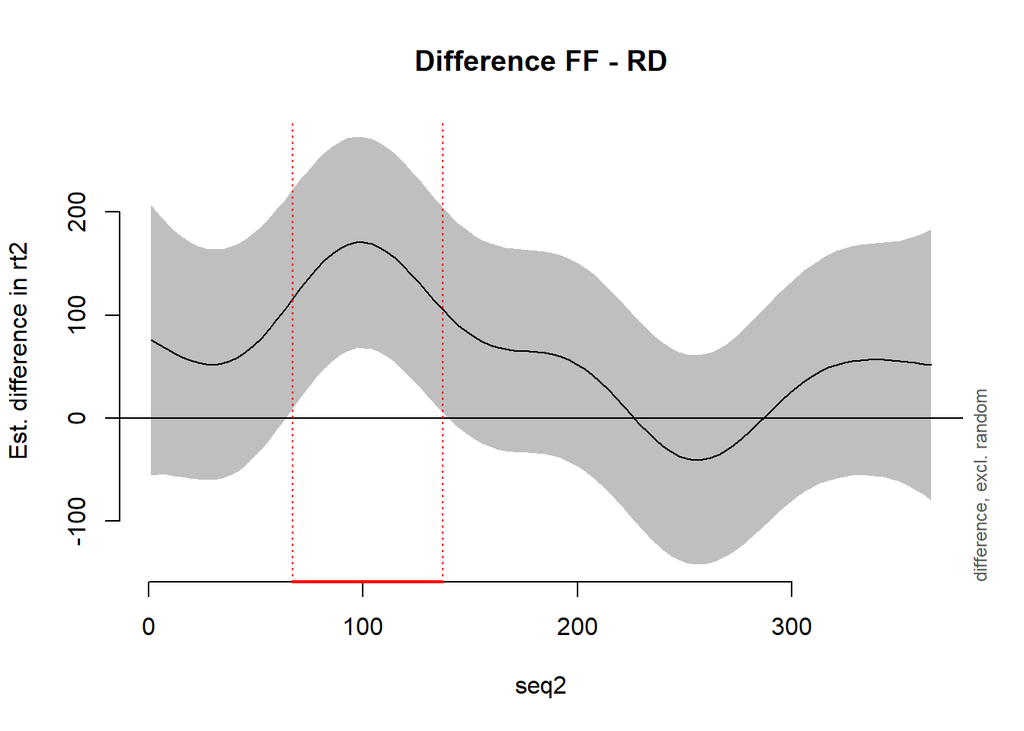

```
##
## seq2 window(s) of significant difference(s):
##  67.181818 - 137.040404
```

```r
plot_diff(m1, view= "seq2" ,comp=list(cond=c("FF","RD")), rm.ranef=TRUE)
```

- Visualize the residuals and check the assumptions of the model. Describe your conclusions (does the model violates the assumptions) and include the code and plots in your report.

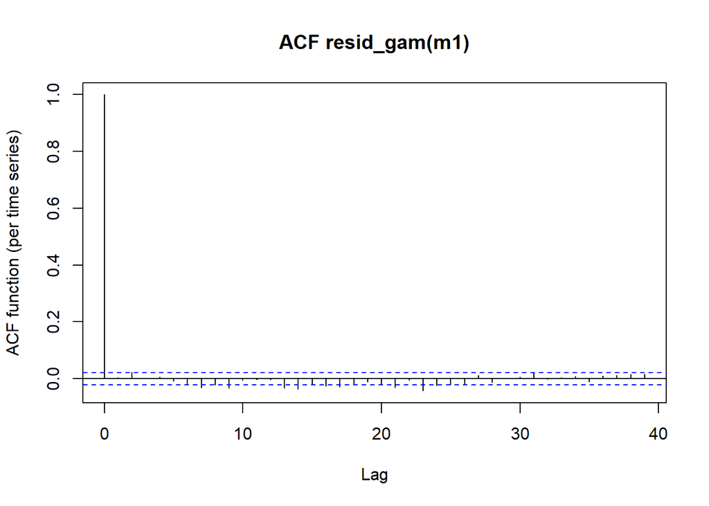

```r
#inspect possible autocorrelation between residuals
acf_resid(m1)
```

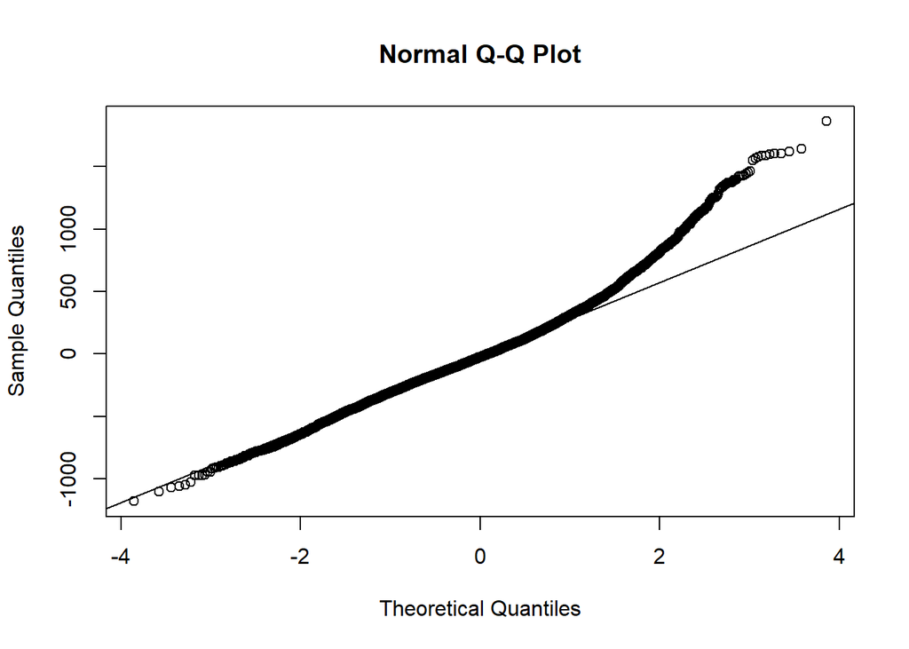

```r
#inspect normality of residuals, structure of residuals of fitted effects and homegeneity of variance
qqnorm(resid(m1))
qqline(resid(m1))
```

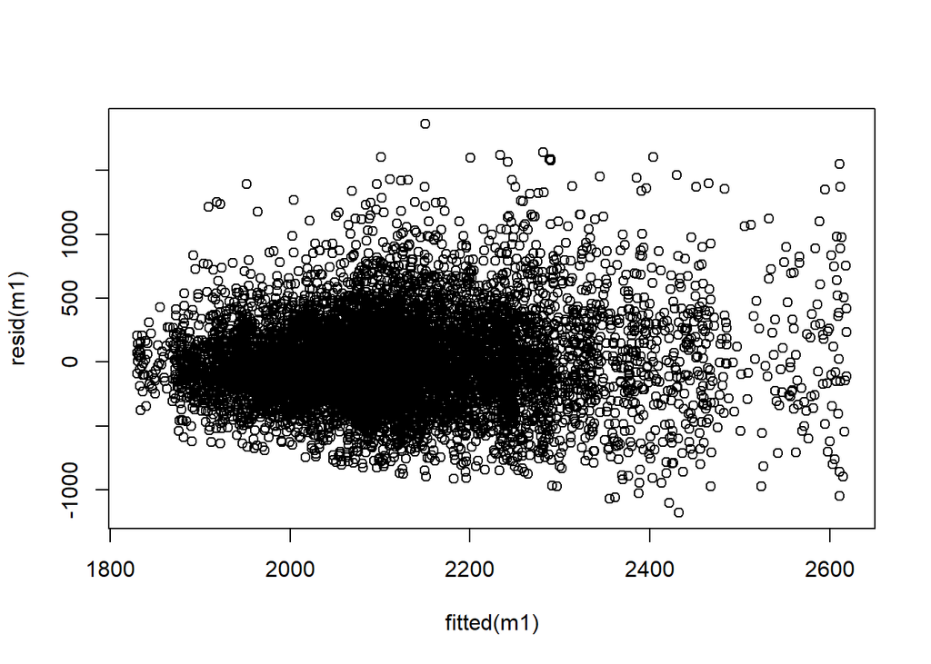

```r
plot(fitted(m1), resid(m1))
```

There is no autocorrelation between residuals